# Code - From little things, big things grow: using applied nucleation to restore marine forests

Catalina A. Musrri Manuscript authors: Catalina A. Musrri1, Georgina Wood2,3, Adriana Vergés4, Alexandra H. Campbell5, Melinda A. Coleman6, Sebastian Vadillo Gonzalez1,4, Peter D. Steinberg4, Ezequiel M. Marzinelli1 1 The University of Sydney, School of Life and Environmental Sciences, Sydney, NSW 2006, Australia 2 College of Science and Engineering, Flinders University, Adelaide SA, Australia 5001 3 UWA Oceans Institute and School of Biological Sciences, University of Western Australia, Perth, WA, Australia 4 Centre for Marine Science and Innovation, School of Biological, Earth and Environmental Sciences, UNSW Sydney, Sydney, NSW, Australia 5 USC Seaweed Research Group, University of the Sunshine Coast, Sunshine Coast, Qld, Australia 6 Department of Primary Industries, National Marine Science Centre, Coffs Harbour, NSW, Australia

2026-04

## Clear the environment

```r
rm(list = ls())
```

## Load packages

*Before loading the packages install them using *install.packages()**

```r
library(summarytools)
library(ggplot2)
library(tidyr)
library(dplyr)
library(readr)
library(vegan)
library(patchwork)
library(ggplot2)
library(pander)
library(lme4)
library(emmeans)
library(wesanderson)
library(corrplot)
library(outliers)
library(MuMIn)
library(ggeffects)
library(GAD)
library(car)
library(mgcv)
library(gamm4)
library(glmmTMB)
library(performance)
library(lmerTest)
library(pander)
```

# **1)** Short term tree island expansion

## **Part 1:** Importing data

```r
data2 <-read.csv("Data&AnalysesPhyll/Crayweed_expansion_LB_short_data.csv", header=TRUE)
```

## **Part 2:** Data structure, manipulation and calculations

1. Check data structure

```r
str(data2)
```

```
## 'data.frame':    52 obs. of  7 variables:
##  $ date     : chr  "16 months" "16 months" "16 months" "16 months" ...
##  $ transect : chr  "T1" "T1" "T2" "T2" ...
##  $ distance : num  0.3 7.4 1 3 5 11 19.5 0.3 4 12 ...
##  $ distance2: int  0 7 1 3 5 11 20 0 4 12 ...
##  $ number   : int  7 1 8 2 2 1 1 4 2 1 ...
##  $ length   : int  22 16 27 43 31 17 43 31 14 21 ...
##  $ stage    : chr  "Juvenile" "Juvenile" "Mature crayweed" "Mature crayweed" ...
```

2. Transform to factor

```r
data2$date <- as.factor(data2$date)
data2$stage<- factor(data2$stage, levels = c("Recruit", "Juvenile" ,"Mature crayweed"))
```

3. Bin data

```r
## Binning distances every 2m for short dataset
data2$bins <- cut(data2$distance, breaks=c(0,0.1,2,4,6,8,10,12,14,16,18,20,22,24,26,28,30,32,34,36,38
                                           ,40,42,44,46,48,50),include.lowest=TRUE,
                  labels=c("0","2","4","6","8","10","12","14","16","18","20","22","24","26","28","30","32",
                           "34","36","38","40","42","44","46","48","50"))
```

4. Summarise data for plotting

```r
bar_plot1 <- data2 %>%
  group_by(date,distance2) %>%
  summarise(mean = mean(number), sd = sd(number), n= n(),
            SE = sd(number)/sqrt(n()), meanlength = mean(length), sdl = sd(length),SEl = sd(length)/sqrt(n()))
```

## **Part 3:** Visualise data: patterns in short-term expansion

1. Crayweed number over time and distance

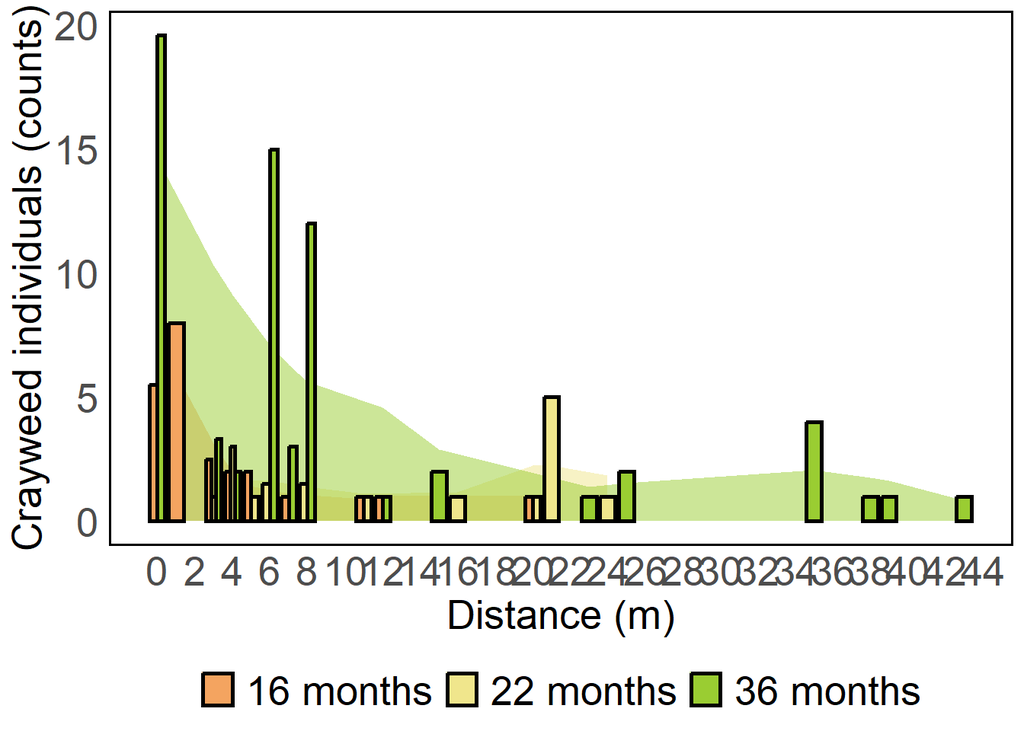

```r
bar_plot1X1 <- ggplot(data = bar_plot1, aes(y = mean, x = distance2, fill=date, colour=date))+
               geom_ribbon(data = bar_plot1[bar_plot1$date == '16 months',],
              aes(ymin = 0, ymax = predict(loess(mean ~ distance2)),
                  fill = date), colour = F, alpha=0.5)+
               geom_ribbon(data = bar_plot1[bar_plot1$date == '22 months',],
                           aes(ymin = 0, ymax = predict(loess(mean ~ distance2)),
                  fill = date), colour = F, alpha=0.5)+
               geom_ribbon(data = bar_plot1[bar_plot1$date == '36 months',],
                           aes(ymin = 0, ymax = predict(loess(mean ~ distance2)),
                               fill = date), colour = F, alpha=0.5)+
   geom_bar(data = bar_plot1, aes(y = mean, x = as.numeric(distance2), fill=date),
                        width=0.8, stat="identity", position= position_dodge(), colour="black", size=1)+
               scale_x_continuous(breaks=seq(0,45,2))+
  scale_fill_manual(values = c("sandybrown", "khaki", "olivedrab3")) +
  xlab("Distance (m)") + ylab("Crayweed individuals (counts)")+
  theme(axis.text.x = element_text(size=20), axis.title.x = element_text(size=20),
        axis.text.y = element_text(size=20), axis.title.y = element_text(size=20),
        axis.ticks = element_blank(), panel.background = element_blank(),
        panel.border = element_rect(fill = NA, colour = "black", size=1),
        legend.position= "bottom", legend.direction="horizontal", legend.text = element_text(size=20),
        legend.title= element_blank(),
        strip.text = element_text(size=20),
        strip.background =element_rect(fill="grey92"),
        plot.title = element_text(size=20))
bar_plot1X1
```

```r
ggsave(bar_plot1X1 , file = "Number_LB.jpg",
         width = 11, height = 6, device="jpeg")
```

2. Crayweed length over time and distance

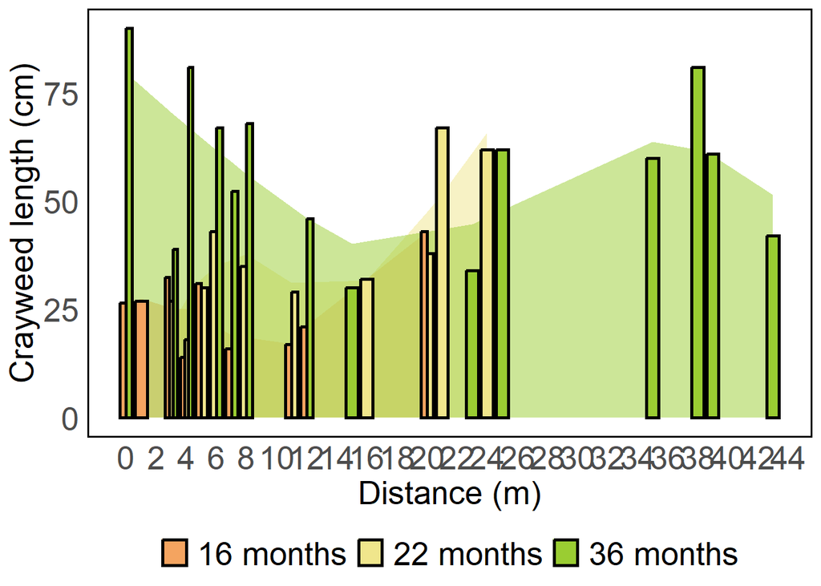

```r
 bar_plot1X2 <- ggplot(data = bar_plot1, aes(y = meanlength, x = distance2, fill=date, colour=date))+
   geom_ribbon(data = bar_plot1[bar_plot1$date == '16 months',],
               aes(ymin = 0, ymax = predict(loess(meanlength ~ distance2)),
                   fill = date), colour = F, alpha=0.5)+
   geom_ribbon(data = bar_plot1[bar_plot1$date == '22 months',],
               aes(ymin = 0, ymax = predict(loess(meanlength ~ distance2)),
                   fill = date), colour = F, alpha=0.5)+
   geom_ribbon(data = bar_plot1[bar_plot1$date == '36 months',],
               aes(ymin = 0, ymax = predict(loess(meanlength ~ distance2)),
                   fill = date), colour = F, alpha=0.5)+
   geom_bar(data = bar_plot1, aes(y = meanlength, x = as.numeric(distance2), fill=date),
            width=0.8, stat="identity", position= position_dodge(), colour="black", size=1)+
   scale_x_continuous(breaks=seq(0,45,2))+
   scale_fill_manual(values = c("sandybrown", "khaki", "olivedrab3")) +
   xlab("Distance (m)") + ylab("Crayweed length (cm)")+
   theme(axis.text.x = element_text(size=20), axis.title.x = element_text(size=20),
         axis.text.y = element_text(size=20), axis.title.y = element_text(size=20),
         axis.ticks = element_blank(), panel.background = element_blank(),
         panel.border = element_rect(fill = NA, colour = "black", size=1),
         legend.position= "bottom", legend.direction="horizontal", legend.text = element_text(size=20),
         legend.title= element_blank(),
         strip.text = element_text(size=20),
         strip.background =element_rect(fill="grey92"),
         plot.title = element_text(size=20))
 bar_plot1X2
```

```r
 ggsave(bar_plot1X2 , file = "Length_LB.jpg",
        width = 11, height = 6, device="jpeg")
```

## **Part 4:** Analyse effect od date and distance

1. Number of crayweed

```r
str(data2)
```

```
## 'data.frame':    52 obs. of  8 variables:
##  $ date     : Factor w/ 3 levels "16 months","22 months",..: 1 1 1 1 1 1 1 1 1 1 ...
##  $ transect : chr  "T1" "T1" "T2" "T2" ...
##  $ distance : num  0.3 7.4 1 3 5 11 19.5 0.3 4 12 ...
##  $ distance2: int  0 7 1 3 5 11 20 0 4 12 ...
##  $ number   : int  7 1 8 2 2 1 1 4 2 1 ...
##  $ length   : int  22 16 27 43 31 17 43 31 14 21 ...
##  $ stage    : Factor w/ 3 levels "Recruit","Juvenile",..: 2 2 3 3 3 2 3 3 2 2 ...
##  $ bins     : Factor w/ 26 levels "0","2","4","6",..: 2 5 2 3 4 7 11 2 3 7 ...
```

```r
model <- glmmTMB(number~ distance2*date + (1|transect) , data=data2, family=poisson(link = "log"))
summary(model)
```

```
##  Family: poisson  ( log )
## Formula:          number ~ distance2 * date + (1 | transect)
## Data: data2
##
##      AIC      BIC   logLik deviance df.resid
##    334.8    348.4   -160.4    320.8       45
##
## Random effects:
##
## Conditional model:
##  Groups   Name        Variance Std.Dev.
##  transect (Intercept) 0.3057   0.5529
## Number of obs: 52, groups:  transect, 6
##
## Conditional model:
##                         Estimate Std. Error z value Pr(>|z|)
## (Intercept)              1.78592    0.33481   5.334  9.6e-08 ***
## distance2               -0.17996    0.05671  -3.174  0.00151 **
## date22 months           -1.33232    0.48142  -2.767  0.00565 **
## date36 months            0.21533    0.30195   0.713  0.47577
## distance2:date22 months  0.20156    0.06341   3.178  0.00148 **
## distance2:date36 months  0.14096    0.05803   2.429  0.01513 *
## ---
## Signif. codes:  0 '***' 0.001 '**' 0.01 '*' 0.05 '.' 0.1 ' ' 1
```

```r
  car::Anova(model)
```

```
## Analysis of Deviance Table (Type II Wald chisquare tests)
##
## Response: number
##                  Chisq Df Pr(>Chisq)
## distance2       9.6517  1   0.001892 **
## date           13.2499  2   0.001327 **
## distance2:date 10.4927  2   0.005267 **
## ---
## Signif. codes:  0 '***' 0.001 '**' 0.01 '*' 0.05 '.' 0.1 ' ' 1
```

```r
r.squaredGLMM(model)
```

```
##                 R2m       R2c
## delta     0.5462619 0.8214293
## lognormal 0.5549580 0.8345059
## trigamma  0.5361432 0.8062136
```

```r
emm3 = emmeans(model, specs = pairwise ~ date|distance2, type = "response", adjust = "none")
emm3
```

```
## $emmeans
## distance2 = 9.35:
##  date      rate    SE  df asymp.LCL asymp.UCL
##  16 months 1.11 0.531 Inf     0.434      2.83
##  22 months 1.93 0.633 Inf     1.012      3.67
##  36 months 5.14 1.329 Inf     3.095      8.53
##
## Confidence level used: 0.95
## Intervals are back-transformed from the log scale
##
## $contrasts
## distance2 = 9.34615384615385:
##  contrast              ratio     SE  df null z.ratio p.value
##  16 months / 22 months 0.576 0.2843 Inf    1  -1.117  0.2638
##  16 months / 36 months 0.216 0.0945 Inf    1  -3.501  0.0005
##  22 months / 36 months 0.375 0.1045 Inf    1  -3.520  0.0004
##
## Tests are performed on the log scale
```

```r
emm3 = emmeans(model, ~ distance2|date, type = "response", adjust = "none") %>%
  test(null = 1)
emm3
```

```
## date = 16 months:
##  distance2 rate    SE  df null z.ratio p.value
##       9.35 1.11 0.531 Inf 2.72  -1.872  0.0612
##
## date = 22 months:
##  distance2 rate    SE  df null z.ratio p.value
##       9.35 1.93 0.633 Inf 2.72  -1.049  0.2941
##
## date = 36 months:
##  distance2 rate    SE  df null z.ratio p.value
##       9.35 5.14 1.329 Inf 2.72   2.462  0.0138
##
## Tests are performed on the log scale
```

```r
check_model(model)
```

```
## `check_outliers()` does not yet support models of class `glmmTMB`.
```

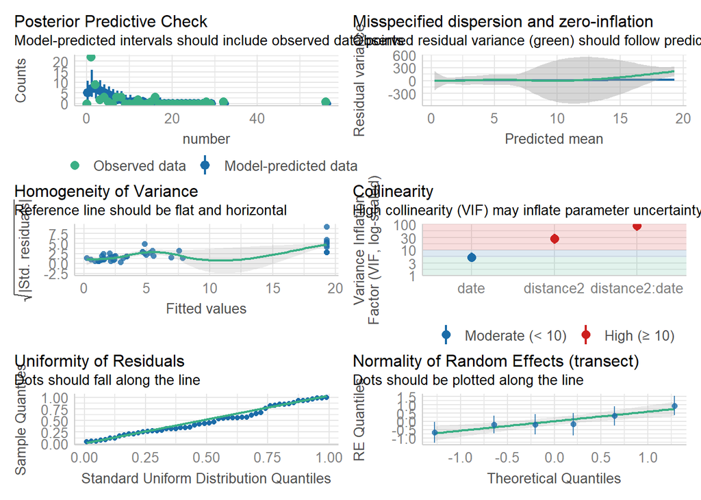

```r
check_overdispersion(model)
```

```
## # Overdispersion test
##
##        dispersion ratio =   3.765
##   Pearson's Chi-Squared = 169.439
##                 p-value = < 0.001
```

```
## Overdispersion detected.
```

2. Lengths

```r
model2 <- glmmTMB(length~ date*distance + (1|transect), data=data2, family=gaussian(link = "log"))
summary(model2)
```

```
##  Family: gaussian  ( log )
## Formula:          length ~ date * distance + (1 | transect)
## Data: data2
##
##      AIC      BIC   logLik deviance df.resid
##    473.1    488.8   -228.6    457.1       44
##
## Random effects:
##
## Conditional model:
##  Groups   Name        Variance  Std.Dev.
##  transect (Intercept)   0.06907  0.2628
##  Residual             318.07953 17.8348
## Number of obs: 52, groups:  transect, 6
##
## Dispersion estimate for gaussian family (sigma^2):  318
##
## Conditional model:
##                         Estimate Std. Error z value Pr(>|z|)
## (Intercept)             3.175607   0.343591   9.242   <2e-16 ***
## date22 months           0.063349   0.429563   0.147    0.883
## date36 months           0.879614   0.345922   2.543    0.011 *
## distance                0.007642   0.035799   0.213    0.831
## date22 months:distance  0.032105   0.039847   0.806    0.420
## date36 months:distance -0.005468   0.036594  -0.149    0.881
## ---
## Signif. codes:  0 '***' 0.001 '**' 0.01 '*' 0.05 '.' 0.1 ' ' 1
```

```r
car::Anova(model2)
```

```
## Analysis of Deviance Table (Type II Wald chisquare tests)
##
## Response: length
##                 Chisq Df Pr(>Chisq)
## date          14.4168  2  0.0007403 ***
## distance       0.9772  1  0.3228972
## date:distance  4.2181  2  0.1213549
## ---
## Signif. codes:  0 '***' 0.001 '**' 0.01 '*' 0.05 '.' 0.1 ' ' 1
```

```r
r.squaredGLMM(model2)
```

```
##               R2m          R2c
## [1,] 0.0004424868 0.0006594855
```

```r
emm3 = emmeans(model2, specs = pairwise ~ date, type = "response", adjust = "none")
```

```
## NOTE: Results may be misleading due to involvement in interactions
```

```r
emm3
```

```
## $emmeans
##  date      response   SE df lower.CL upper.CL
##  16 months     25.7 6.66 44     15.2     43.4
##  22 months     37.0 7.13 44     25.1     54.5
##  36 months     58.9 8.02 44     44.7     77.5
##
## Confidence level used: 0.95
## Intervals are back-transformed from the log scale
##
## $contrasts
##  contrast              ratio    SE df null t.ratio p.value
##  16 months / 22 months 0.696 0.203 44    1  -1.244  0.2201
##  16 months / 36 months 0.437 0.107 44    1  -3.383  0.0015
##  22 months / 36 months 0.628 0.116 44    1  -2.512  0.0158
##
## Tests are performed on the log scale
```

```r
check_model(model2)
```

```
## `check_outliers()` does not yet support models of class `glmmTMB`.
```

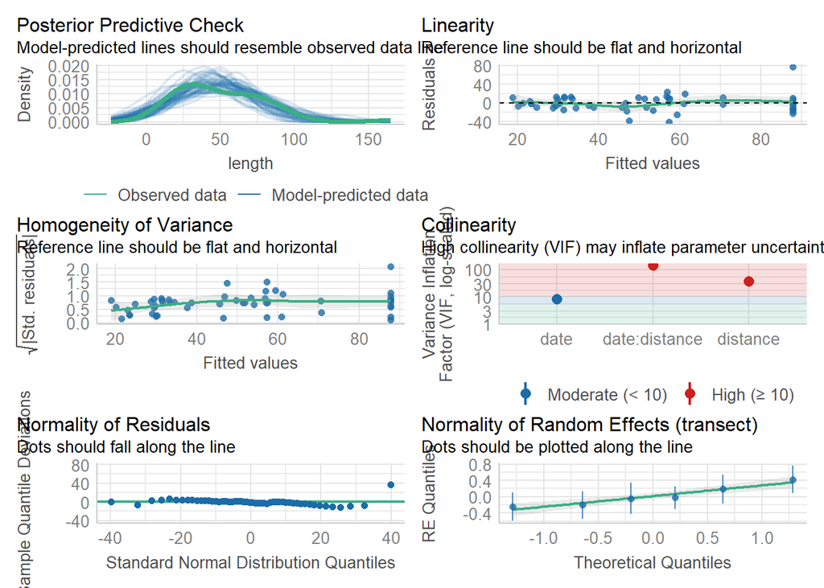

```r
check_overdispersion(model2)
```

```
## # Overdispersion test
##
##  dispersion ratio = 1.199
##           p-value = 0.384
```

```
## No overdispersion detected.
```

# **2)** 2. Factors associated with short-term establishment

## **Part 1:** Importing data

```r
Sites_Metadata <- read.csv("Data&AnalysesPhyll/Sites_Metadata.csv")
Benthic_all <- read.csv("Data&AnalysesPhyll/BenthicCover_Restanalysis.csv")
Recruitment_density <- read.csv("Data&AnalysesPhyll/Recruitment_Density.csv")
Recruits_size <- read.csv("Data&AnalysesPhyll/Recruits_Size.csv")
Species <- read.csv("Data&AnalysesPhyll/Species.csv")
Survival_transplants <- read.csv("Data&AnalysesPhyll/Survival_Transplants.csv")
Environmental <- read_csv("Data&AnalysesPhyll/Loggers_Restored.csv",
    col_types = cols(Date = col_date(format = "%d/%m/%Y")))
Gforce <-read_csv("Data&AnalysesPhyll/Gforce.csv",
    col_types = cols(Date = col_date(format = "%d/%m/%Y")))
Cryptic_V1 <- read.csv("Data&AnalysesPhyll/Cryptic_data.csv")
Mobile_fish <- read.csv("Data&AnalysesPhyll/Mobile_fish_S2.csv")
Species_mobile <- read.csv("Data&AnalysesPhyll/Species_mobilefish.csv")
Condition <- read.csv("Data&AnalysesPhyll/Condition_Transplants_overtime.csv")
```

## **Part 2:** Data structure, manipulation and calculations

In this section data sets are manipulated for future analysis. New data sets of mean values were created.

### **2a)** Site metadata

1. Explore data

```r
str(Sites_Metadata)
```

```
## 'data.frame':    18 obs. of  19 variables:
##  $ Site                  : chr  "BUNGAN BEACH" "LONG REEF" "DEE WHY" "SOUTH BONDI" ...
##  $ Latitude              : num  -33.7 -33.7 -33.8 -33.9 -33.9 ...
##  $ Longitude             : num  151 151 151 151 151 ...
##  $ Site_Code             : chr  "BU" "LR" "DY" "SB" ...
##  $ Status                : chr  "CONTROL" "CONTROL" "CONTROL" "CONTROL" ...
##  $ Crayweed              : chr  "Absent " "Absent " "Absent " "Absent " ...
##  $ Logger_deployed       : chr  "Yes" "Yes" "Yes" "Yes" ...
##  $ UVC_period1           : chr  "No" "Yes" "Yes" "No" ...
##  $ UVC_period2           : chr  "Yes" "Yes" "Yes" "Yes" ...
##  $ UVC_Period3           : chr  "Yes" "Yes" "Yes" "Yes" ...
##  $ Benthic._cover_Period1: chr  "No" "Yes" "Yes" "No" ...
##  $ Benthic._cover_Period2: chr  "Yes" "Yes" "Yes" "Yes" ...
##  $ Benthic._cover_Period3: chr  "Yes" "Yes" "Yes" "Yes" ...
##  $ Survey_Period1        : logi  NA NA NA NA NA NA ...
##  $ Survey_Period2        : logi  NA NA NA NA NA NA ...
##  $ Survey_Period3        : logi  NA NA NA NA NA NA ...
##  $ Date_1                : logi  NA NA NA NA NA NA ...
##  $ Date_2                : logi  NA NA NA NA NA NA ...
##  $ Date_3                : logi  NA NA NA NA NA NA ...
```

### **2b)** Recruitment density

1. Explore data structure

```r
str(Sites_Metadata)
```

```
## 'data.frame':    18 obs. of  19 variables:
##  $ Site                  : chr  "BUNGAN BEACH" "LONG REEF" "DEE WHY" "SOUTH BONDI" ...
##  $ Latitude              : num  -33.7 -33.7 -33.8 -33.9 -33.9 ...
##  $ Longitude             : num  151 151 151 151 151 ...
##  $ Site_Code             : chr  "BU" "LR" "DY" "SB" ...
##  $ Status                : chr  "CONTROL" "CONTROL" "CONTROL" "CONTROL" ...
##  $ Crayweed              : chr  "Absent " "Absent " "Absent " "Absent " ...
##  $ Logger_deployed       : chr  "Yes" "Yes" "Yes" "Yes" ...
##  $ UVC_period1           : chr  "No" "Yes" "Yes" "No" ...
##  $ UVC_period2           : chr  "Yes" "Yes" "Yes" "Yes" ...
##  $ UVC_Period3           : chr  "Yes" "Yes" "Yes" "Yes" ...
##  $ Benthic._cover_Period1: chr  "No" "Yes" "Yes" "No" ...
##  $ Benthic._cover_Period2: chr  "Yes" "Yes" "Yes" "Yes" ...
##  $ Benthic._cover_Period3: chr  "Yes" "Yes" "Yes" "Yes" ...
##  $ Survey_Period1        : logi  NA NA NA NA NA NA ...
##  $ Survey_Period2        : logi  NA NA NA NA NA NA ...
##  $ Survey_Period3        : logi  NA NA NA NA NA NA ...
##  $ Date_1                : logi  NA NA NA NA NA NA ...
##  $ Date_2                : logi  NA NA NA NA NA NA ...
##  $ Date_3                : logi  NA NA NA NA NA NA ...
```

2. Filter data - To maintain only the sites and time-points needed for this work

```r
Recruitment_density <- Recruitment_density %>%
replace(is.na(.),0) %>%
filter(Site_Code == "SO"| Site_Code == "MA"|Site_Code == "CO"|Site_Code == "FW"| Site_Code == "WB") %>%
filter(Time_Point == "6_months" | Time_Point == "9_months" )


Recruitment_density$Mat_code <- paste(Recruitment_density$Site_Code,Recruitment_density$Mat)
```

3. Calculate means by site

```r
Recruitment_mean <- Recruitment_density %>%
  group_by (Site_Code, Time_Point) %>%
  summarise(Recruitment_mean = mean(Total_recruitment), n = n(), sd = sd(Total_recruitment), se = sd/sqrt(n), Total_number = sum(Total_recruitment))
```

### **2c)** Recruits_size

1. Check structure

```r
str (Recruits_size)
```

```
## 'data.frame':    51 obs. of  9 variables:
##  $ Time_Point             : chr  "6_months" "6_months" "6_months" "6_months" ...
##  $ Site_Code              : chr  "CO" "CO" "CO" "CO" ...
##  $ Mat                    : int  2 3 5 6 1 2 3 4 5 6 ...
##  $ Recruit_size_inside_mat: num  13.5 3 3 3.5 8.67 ...
##  $ X                      : logi  NA NA NA NA NA NA ...
##  $ X.1                    : logi  NA NA NA NA NA NA ...
##  $ X.2                    : logi  NA NA NA NA NA NA ...
##  $ X.3                    : logi  NA NA NA NA NA NA ...
##  $ X.4                    : chr  "" "" "" "" ...
```

2. Add and remove data

```r
Recruits_length <- Recruits_size %>%
filter(Site_Code == "SO"| Site_Code == "MA"|Site_Code == "CO"|Site_Code == "FW"| Site_Code == "WB") %>%
filter(Time_Point == "6_months" | Time_Point == "9_months")

Recruits_length1 <- Recruits_length %>%
na.omit()

Recruits_length$Mat_code <- paste(Recruits_length$Site_Code,Recruits_length$Mat)
```

2. Find outliers

```r
test <- grubbs.test(Recruits_length$Recruit_size_inside_mat)
test
```

```
##
##  Grubbs test for one outlier
##
## data:  Recruits_length$Recruit_size_inside_mat
## G = 2.24414, U = 0.86021, p-value = 0.3944
## alternative hypothesis: highest value 14 is an outlier
```

3. Calculate means by site

```r
Recruits_size_mean <- Recruits_length %>%
  group_by (Site_Code, Time_Point) %>%
  summarise(Recruit_size_mean = mean(Recruit_size_inside_mat, na.rm = TRUE), n = n(), sd = sd(Recruit_size_inside_mat, na.rm = TRUE), se = sd/sqrt(n))
```

### **2d)** Survival transplants

1. Check structure

```r
str(Survival_transplants)
```

```
## 'data.frame':    210 obs. of  7 variables:
##  $ Time_Point         : chr  "0_months" "0_months" "0_months" "0_months" ...
##  $ Site_Code          : chr  "WB" "WB" "WB" "WB" ...
##  $ Mat                : int  1 2 3 4 5 6 1 2 3 4 ...
##  $ Sample_Code        : chr  "WB1" "WB2" "WB3" "WB4" ...
##  $ PROVENANCE         : chr  "North" "North" "North" "North" ...
##  $ Individuals_alive  : int  15 15 15 15 15 15 15 15 15 15 ...
##  $ Survival_Percentage: num  100 100 100 100 100 100 100 100 100 100 ...
```

2. Filter data

```r
Survival <- Survival_transplants %>%
replace(is.na(.),0) %>%
filter(Site_Code == "SO"| Site_Code == "MA"|Site_Code == "CO"|Site_Code == "FW"| Site_Code == "WB") %>%
filter(Time_Point == "6_months" | Time_Point == "9_months")
```

3. Calculate means by site

```r
Survival_site <- Survival %>%
  group_by (Site_Code, Time_Point) %>%
  summarise(Survival_Percentage = mean(Survival_Percentage), coef_Survival_Percentage = (sd(Survival_Percentage)/ mean(Survival_Percentage)) * 100)
```

### **2e)** Condition transplants

1. Check data structure

```r
str(Condition)
```

```
## 'data.frame':    322 obs. of  6 variables:
##  $ Time_Point         : chr  "3_months" "3_months" "3_months" "3_months" ...
##  $ Site_Code          : chr  "SO" "SO" "SO" "SO" ...
##  $ PROVENANCE         : chr  "North" "North" "North" "North" ...
##  $ Percentag_fouled   : int  0 10 10 10 10 10 0 0 0 10 ...
##  $ Grazing            : num  NA 1 0 0.5 1 2 0.5 1 1 1 ...
##  $ Percentage_bleached: int  0 5 15 5 5 10 5 5 5 5 ...
```

2. Filter data

```r
Condition <- Condition %>%
na.omit()

Condition6m <-  Condition%>%
  filter(Time_Point == "6_months")
```

3. Calculate means by site

```r
Condition_site <- Condition6m %>%
  group_by (Site_Code, Time_Point) %>%
  summarise(Percentage_fouling = mean(Percentag_fouled),n = n(), sd_fouling = sd(Percentag_fouled), se_fouling = sd_fouling/sqrt(n), Mean_Grazing = mean(Grazing), sd_grazing = sd(Grazing), se_grazing = sd_grazing/sqrt(n), mean_bleaching = mean(Percentage_bleached),n = n(), sd_bleaching = sd(Percentage_bleached), se_bleaching = sd_bleaching/sqrt(n))
```

### **2f)** Benthic data

1. Check Structure

```r
str(Benthic_all)
```

```
## 'data.frame':    202 obs. of  17 variables:
##  $ Time                 : chr  "AFTER" "AFTER" "AFTER" "AFTER" ...
##  $ Status               : chr  "TRANSPLANT" "TRANSPLANT" "TRANSPLANT" "TRANSPLANT" ...
##  $ Site_Code            : chr  "CO" "CO" "CO" "CO" ...
##  $ Survey_Period        : int  3 3 3 3 3 3 3 3 3 3 ...
##  $ Transect             : int  1 1 1 1 1 2 2 2 2 2 ...
##  $ Photo                : chr  "CO_S2_T1PC220075.JPG" "CO_S2_T1PC220076.JPG" "CO_S2_T1PC220084.JPG" "CO_S2_T1PC220090.JPG" ...
##  $ Animal               : int  0 0 10 0 0 0 0 0 5 0 ...
##  $ CA                   : int  0 10 0 0 0 0 0 0 5 5 ...
##  $ Crayweed             : int  0 0 0 0 0 0 0 0 0 0 ...
##  $ Encrusting_macroalgae: int  90 25 15 5 90 5 15 0 5 0 ...
##  $ Ecklonia             : int  0 10 0 0 0 0 0 35 0 0 ...
##  $ Sargassum            : int  5 55 0 25 0 0 0 40 10 10 ...
##  $ Caulerpa             : int  0 0 0 0 0 0 0 0 0 0 ...
##  $ Understory           : int  5 0 70 55 5 45 70 5 10 60 ...
##  $ Substrate            : int  0 0 5 15 5 50 15 20 65 25 ...
##  $ Unknown              : int  0 0 0 0 0 0 0 0 0 0 ...
##  $ Total                : int  100 100 100 100 100 100 100 100 100 100 ...
```

2. Filter data

```r
Benthic_all$Survey_Period <- as.factor(Benthic_all$Survey_Period)

Benthic_rest <- Benthic_all %>%
replace(is.na(.),0)  %>%
  filter(Site_Code != "NB")  %>%
  dplyr::select(-Total)
```

3. Transform to long format

```r
Benthic_long <- Benthic_rest %>%
  gather(Cover_type, Cover_percentage, Animal:Unknown)
```

4. Calculate mean, sd, and se by cover type

```r
Benthic_mean <- Benthic_long %>%
  group_by(Site_Code, Survey_Period, Time, Cover_type)%>%
  summarise(Mean_cover = mean(Cover_percentage),n = n(), sd = sd(Cover_percentage), se = sd/sqrt(n))
```

5. Calculate means by site for all times

```r
Benthic_sitemerged <- Benthic_long %>%
  group_by (Site_Code, Cover_type) %>%
  summarise(Mean_Cover = mean(Cover_percentage),n = n(), sd = sd(Cover_percentage), se = sd/sqrt(n))
```

### **2g)** Loggers data

1. Check data structure

```r
str(Environmental)
```

```
## spc_tbl_ [50,255 × 7] (S3: spec_tbl_df/tbl_df/tbl/data.frame)
##  $ Site_Code          : chr [1:50255] "CO" "CO" "CO" "CO" ...
##  $ #                  : num [1:50255] 1 2 3 4 5 6 7 8 9 10 ...
##  $ Date_Time_GMT+11:00: chr [1:50255] "12/13/17 06:00:00 am" "12/13/17 06:30:00 am" "12/13/17 07:00:00 am" "12/13/17 07:30:00 am" ...
##  $ Date               : Date[1:50255], format: "2017-12-13" "2017-12-13" ...
##  $ Time               : 'hms' num [1:50255] 06:00:00 06:30:00 07:00:00 07:30:00 ...
##   ..- attr(*, "units")= chr "secs"
##  $ Temp_C             : num [1:50255] 19.4 19.3 19.6 19.7 19.9 ...
##  $ Intensity_luX      : num [1:50255] 388 1324 2411 3789 4822 ...
##  - attr(*, "spec")=
##   .. cols(
##   ..   Site_Code = col_character(),
##   ..   `#` = col_double(),
##   ..   `Date_Time_GMT+11:00` = col_character(),
##   ..   Date = col_date(format = "%d/%m/%Y"),
##   ..   Time = col_time(format = ""),
##   ..   Temp_C = col_double(),
##   ..   Intensity_luX = col_double()
##   .. )
##  - attr(*, "problems")=<externalptr>
```

2. Filter data

```r
Environmental_lux <- Environmental %>%
  filter(Intensity_luX > 100) #Remove low values that may indicate that the logger was buried
```

3. Calculate daily mean for Temperature and Light intensity

```r
Temp_day <- Environmental %>%
  group_by(Site_Code, Date)%>%
  summarise(Temp_C = mean(Temp_C),n= n(), sd_temp = sd(Temp_C), se_temp = sd_temp/sqrt(n))

Lux_day <- Environmental_lux %>%
  group_by(Site_Code, Date)%>%
  summarise(Mean_Intensity1 = mean(Intensity_luX),n= n(), sd_lux = sd(Intensity_luX), se_lux = sd_lux/sqrt(n))
```

4. Visualise data variation
- Light intensity

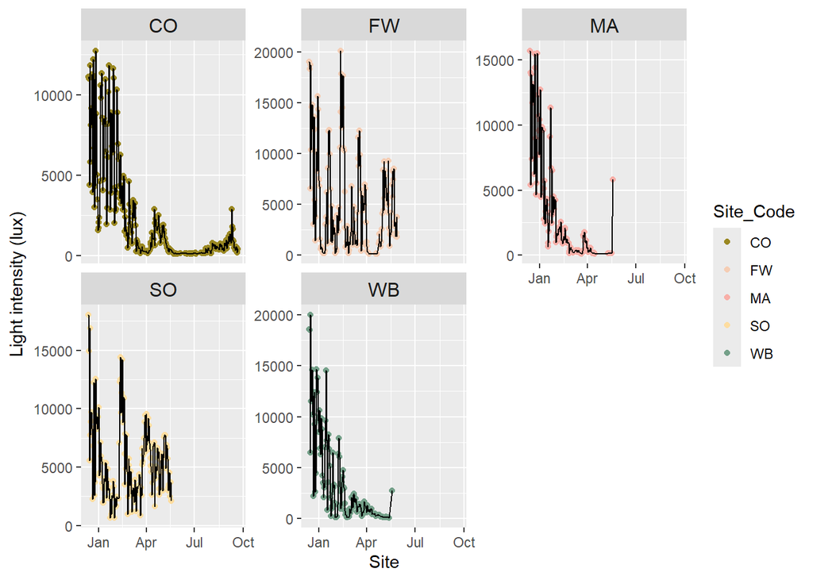

```r
Lux_day %>%
 ggplot(aes(x= Date, y= Mean_Intensity1)) +
geom_point(aes(color = Site_Code)) +
geom_line()+
labs(y = expression ("Light intensity (lux)"), x = "Site") +
facet_wrap(~ Site_Code, scales = "free_y") +
theme(strip.text.x = element_text(size = 12)) +
scale_color_manual(values=wes_palette(n=5, name="Royal2"))
```

* Temperature

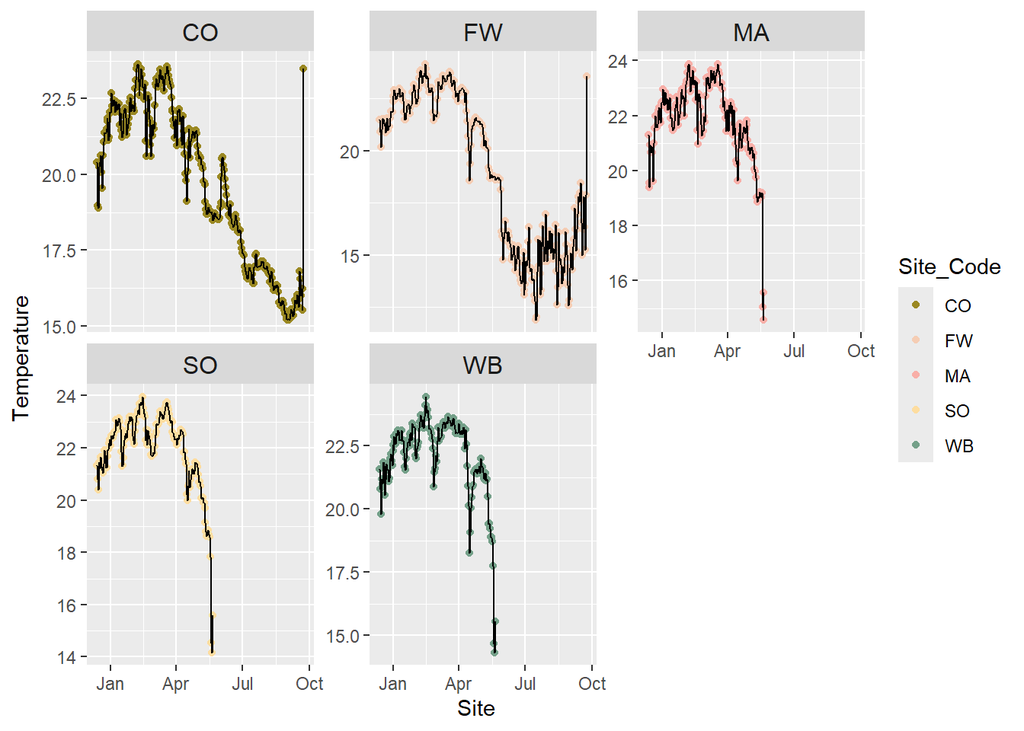

```r
Temp_day %>%
 ggplot(aes(x= Date, y= Temp_C)) +
geom_point(aes(color = Site_Code)) +
geom_line()+
labs(y = expression ("Temperature"), x = "Site") +
facet_wrap(~ Site_Code, scales = "free_y") +
theme(strip.text.x = element_text(size = 12)) +
scale_color_manual(values=wes_palette(n=5, name="Royal2"))
```

5) Maintain consistent data